# Sintetik Səhiyyə Məlumatlarının Analizi

Aysu İ

2026-05-10

# 1 Giriş

Bu layihədə **sintetik səhiyyə məlumat dəsti** təhlil edilir. Məlumat dəsti üç əsas cədvəldən ibarətdir:

- **patients** — pasiyentlərin demoqrafik məlumatları
- **encounters** — tibbi müraciətlər
- **observations** — klinik ölçülər (BMI, qan təzyiqi, xolesterin və s.)

Layihənin məqsədi bu üç cədvəli birləşdirərək hərtərəfli deskriptiv təhlil aparmaq, məlumat keyfiyyətini qiymətləndirmək, anomaliyaları aşkar etmək, dəyişənlər arasındakı əlaqəni statistik testlərlə ölçmək və reqressiya modeli qurmaqdan ibarətdir.

# 2 Paketlər və Məlumatın Yüklənməsi

```r
if (!requireNamespace("data.table",  quietly = TRUE)) install.packages("data.table")
if (!requireNamespace("ggplot2",     quietly = TRUE)) install.packages("ggplot2")
if (!requireNamespace("dplyr",       quietly = TRUE)) install.packages("dplyr")
if (!requireNamespace("lubridate",   quietly = TRUE)) install.packages("lubridate")
if (!requireNamespace("scales",      quietly = TRUE)) install.packages("scales")
if (!requireNamespace("knitr",       quietly = TRUE)) install.packages("knitr")
if (!requireNamespace("kableExtra",  quietly = TRUE)) install.packages("kableExtra")
if (!requireNamespace("car",         quietly = TRUE)) install.packages("car")
if (!requireNamespace("caret",       quietly = TRUE)) install.packages("caret")

library(data.table)
library(ggplot2)
library(dplyr)
library(lubridate)
library(scales)
library(knitr)
library(kableExtra)
library(car)
library(caret)
```

```r
patients     <- readRDS("patients.rds")
encounters   <- readRDS("encounters.rds")
observations <- readRDS("observations.rds")

setDT(patients)
setDT(encounters)
setDT(observations)

setnames(patients,     tolower(names(patients)))
setnames(encounters,   tolower(names(encounters)))
setnames(observations, tolower(names(observations)))

cat("Patients sətir sayı:     ", format(nrow(patients),     big.mark=","), "\n")
```

```
## Patients sətir sayı:      132,607
```

```r
cat("Encounters sətir sayı:   ", format(nrow(encounters),   big.mark=","), "\n")
```

```
## Encounters sətir sayı:    1,263,669
```

```r
cat("Observations sətir sayı: ", format(nrow(observations), big.mark=","), "\n")
```

```
## Observations sətir sayı:  5,383,318
```

# 3 Məlumat Keyfiyyəti və Təmizlik

## 3.1 NA Analizi

```r
# Patients NA faizləri
na_patients <- sapply(patients, function(x) round(mean(is.na(x)) * 100, 1))
na_pat_dt <- data.table(Sutun = names(na_patients), NA_faiz = na_patients)
na_pat_dt <- na_pat_dt[order(-NA_faiz)]

kable(na_pat_dt, col.names = c("Sütun", "NA Faizi (%)"),
      caption = "Patients Cədvəlində NA Paylanması") |>
  kable_styling(bootstrap_options = c("striped","hover","condensed"),
                full_width = FALSE) |>
  row_spec(which(na_pat_dt$NA_faiz > 50), color = "red")
```

Patients Cədvəlində NA Paylanması

| Sütun | NA Faizi (%) |
| --- | --- |
| deathdate | 75.1 |
| id | 0.0 |
| birthdate | 0.0 |
| ssn | 0.0 |
| drivers | 0.0 |
| passport | 0.0 |
| prefix | 0.0 |
| first | 0.0 |
| last | 0.0 |
| suffix | 0.0 |
| maiden | 0.0 |
| marital | 0.0 |
| race | 0.0 |
| ethnicity | 0.0 |
| gender | 0.0 |
| birthplace | 0.0 |
| address | 0.0 |

```r
# Encounters NA faizləri
na_encounters <- sapply(encounters, function(x) round(mean(is.na(x)) * 100, 1))
na_enc_dt <- data.table(Sutun = names(na_encounters), NA_faiz = na_encounters)
na_enc_dt <- na_enc_dt[order(-NA_faiz)]

kable(na_enc_dt, col.names = c("Sütun", "NA Faizi (%)"),
      caption = "Encounters Cədvəlində NA Paylanması") |>
  kable_styling(bootstrap_options = c("striped","hover","condensed"),
                full_width = FALSE)
```

Encounters Cədvəlində NA Paylanması

| Sütun | NA Faizi (%) |
| --- | --- |
| id | 0 |
| date | 0 |
| patient | 0 |
| code | 0 |
| description | 0 |
| reasoncode | 0 |
| reasondescription | 0 |

```r
# Observations NA faizləri
na_obs <- sapply(observations, function(x) round(mean(is.na(x)) * 100, 1))
na_obs_dt <- data.table(Sutun = names(na_obs), NA_faiz = na_obs)

kable(na_obs_dt, col.names = c("Sütun", "NA Faizi (%)"),
      caption = "Observations Cədvəlində NA Paylanması") |>
  kable_styling(bootstrap_options = c("striped","hover","condensed"),
                full_width = FALSE)
```

Observations Cədvəlində NA Paylanması

| Sütun | NA Faizi (%) |
| --- | --- |
| date | 0 |
| patient | 0 |
| encounter | 0 |
| code | 0 |
| description | 0 |
| value | 0 |
| units | 0 |

> **Şərh:** NA analizi hər sütundakı çatışmayan məlumatın faizini göstərir. Yüksək NA faizli sütunlar (qırmızı) analiz zamanı ehtiyatla istifadə edilməlidir.

## 3.2 Dublikat Yoxlaması

```r
dup_patients   <- sum(duplicated(patients,   by = "id"))
dup_encounters <- sum(duplicated(encounters, by = "id"))

cat("Patients dublikat sayı:   ", dup_patients,   "\n")
```

```
## Patients dublikat sayı:    0
```

```r
cat("Encounters dublikat sayı: ", dup_encounters, "\n")
```

```
## Encounters dublikat sayı:  0
```

## 3.3 Məntiqi Xətalı Qeydlər

```r
# deathdate < birthdate olan qeydlər
patients[, birthdate := as.Date(birthdate)]
patients[, deathdate := as.Date(deathdate)]

xeta <- patients[!is.na(deathdate) & deathdate < birthdate, .N]
cat("deathdate < birthdate olan xətalı qeyd sayı:", xeta, "\n")
```

```
## deathdate < birthdate olan xətalı qeyd sayı: 0
```

```r
# Məntiqdışı qeydləri çıxar
patients <- patients[is.na(deathdate) | deathdate >= birthdate]
```

## 3.4 Tarix Formatlaması və Yaş Hesablanması

```r
# Sys.Date() — sənəd hər işlədildikdə cari tarixi götürür
bugun <- Sys.Date()

encounters[,   date := as.Date(date)]
observations[, date := as.Date(date)]

# Yaş hesablanması: sağ olanlar üçün bugünkü tarix, vəfat edənlər üçün ölüm tarixi
patients[is.na(deathdate),  yas := as.numeric(bugun - birthdate) / 365.25]
patients[!is.na(deathdate), yas := as.numeric(deathdate - birthdate) / 365.25]

# Məntiqdışı yaşları çıxar
patients <- patients[yas >= 0 & yas <= 120]

cat("Cari tarix (Sys.Date()):", format(bugun), "\n")
```

```
## Cari tarix (Sys.Date()): 2026-05-10
```

```r
cat("Yaş hesablanmış pasiyent sayı:", format(nrow(patients), big.mark=","), "\n")
```

```
## Yaş hesablanmış pasiyent sayı: 132,607
```

## 3.5 fcase() ilə Yaş Kateqoriyaları

```r
# fcase() — data.table-in native funksiyası (case_when əvəzinə)
patients[, yas_cat := fcase(
  yas <  18,            "Usaq (0-17)",
  yas >= 18 & yas < 35, "Genc (18-34)",
  yas >= 35 & yas < 55, "Orta yas (35-54)",
  yas >= 55 & yas < 70, "Boyuk yas (55-69)",
  yas >= 70,            "Yasli (70+)"
)]

patients[, yas_cat := factor(yas_cat, levels = c(
  "Usaq (0-17)", "Genc (18-34)", "Orta yas (35-54)",
  "Boyuk yas (55-69)", "Yasli (70+)"
))]

patients[, .N, by = yas_cat][order(yas_cat)] |>
  kable(col.names = c("Yas Kateqoriyasi", "Pasiyent Sayi"),
        caption = "Yas Kateqoriyalari uzre Pasiyent Sayi") |>
  kable_styling(bootstrap_options = c("striped","hover","condensed"),
                full_width = FALSE)
```

Yas Kateqoriyalari uzre Pasiyent Sayi

| Yas Kateqoriyasi | Pasiyent Sayi |
| --- | --- |
| Usaq (0-17) | 12470 |
| Genc (18-34) | 25047 |
| Orta yas (35-54) | 34729 |
| Boyuk yas (55-69) | 31829 |
| Yasli (70+) | 28532 |

## 3.6 Observations Cədvəlindəki Bütün Göstəricilər

```r
# Observations-dakı bütün description növləri
obs_novler <- observations[, .N, by = description][order(-N)]

kable(obs_novler[1:20], col.names = c("Klinik Gostərici", "Olcu Sayi"),
      caption = "Observations Cedvelindeki En Cox 20 Gostərici") |>
  kable_styling(bootstrap_options = c("striped","hover","condensed"),
                full_width = FALSE)
```

Observations Cedvelindeki En Cox 20 Gostərici

| Klinik Gostərici | Olcu Sayi |
| --- | --- |
| Body Height | 588656 |
| Body Weight | 588656 |
| Systolic Blood Pressure | 588656 |
| Diastolic Blood Pressure | 588656 |
| Body Mass Index | 518213 |
| Hemoglobin A1c/Hemoglobin.total in Blood | 316248 |
| Glucose | 158124 |
| Urea Nitrogen | 158124 |
| Creatinine | 158124 |
| Calcium | 158124 |
| Sodium | 158124 |
| Potassium | 158124 |
| Chloride | 158124 |
| Carbon Dioxide | 158124 |
| Total Cholesterol | 136031 |
| Triglycerides | 136031 |
| Low Density Lipoprotein Cholesterol | 136031 |
| High Density Lipoprotein Cholesterol | 136031 |
| Estimated Glomerular Filtration Rate | 129174 |
| Oral temperature | 53781 |

> **Şərh:** Observations cədvəlində çoxsaylı klinik göstərici mövcuddur. Analiz üçün BMI, sistol/diastolik qan təzyiqi, xolesterin və qan şəkəri seçilmişdir.

# 4 Deskriptiv Təhlil

## 4.1 Pasiyentlər (Patients)

### 4.1.1 Ümumi Statistika

```r
yas_stat <- patients[, .(
  `Orta Yas`   = round(mean(yas, na.rm=TRUE), 1),
  `Median Yas` = round(median(yas, na.rm=TRUE), 1),
  `Std Sapma`  = round(sd(yas, na.rm=TRUE), 1),
  `Min Yas`    = round(min(yas, na.rm=TRUE), 1),
  `Max Yas`    = round(max(yas, na.rm=TRUE), 1)
)]

kable(yas_stat, caption = "Pasiyent Yasinin Deskriptiv Statistikasi") |>
  kable_styling(bootstrap_options = c("striped","hover"), full_width = FALSE)
```

Pasiyent Yasinin Deskriptiv Statistikasi

| Orta Yas | Median Yas | Std Sapma | Min Yas | Max Yas |
| --- | --- | --- | --- | --- |
| 50.3 | 51.9 | 22.3 | 0 | 108.4 |

### 4.1.2 Cins Paylanması

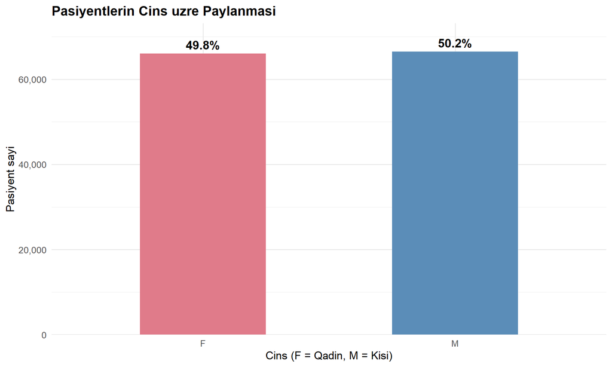

```r
cins <- patients[, .N, by = gender]
cins[, faiz := round(N / sum(N) * 100, 1)]

ggplot(cins, aes(x = gender, y = N, fill = gender)) +
  geom_col(width = 0.5, show.legend = FALSE) +
  geom_text(aes(label = paste0(faiz, "%")), vjust = -0.5, size = 5, fontface = "bold") +
  scale_fill_manual(values = c("F" = "#e07b8a", "M" = "#5b8db8")) +
  scale_y_continuous(labels = comma, expand = expansion(mult = c(0, 0.1))) +
  labs(title = "Pasiyentlerin Cins uzre Paylanmasi",
       x = "Cins (F = Qadin, M = Kisi)", y = "Pasiyent sayi") +
  theme_minimal(base_size = 13) +
  theme(plot.title = element_text(face = "bold"))
```

> **Şərh:** Məlumat dəstindəki pasiyentlər cins baxımından demək olar ki bərabər paylanmışdır.

### 4.1.3 Yaş Paylanması

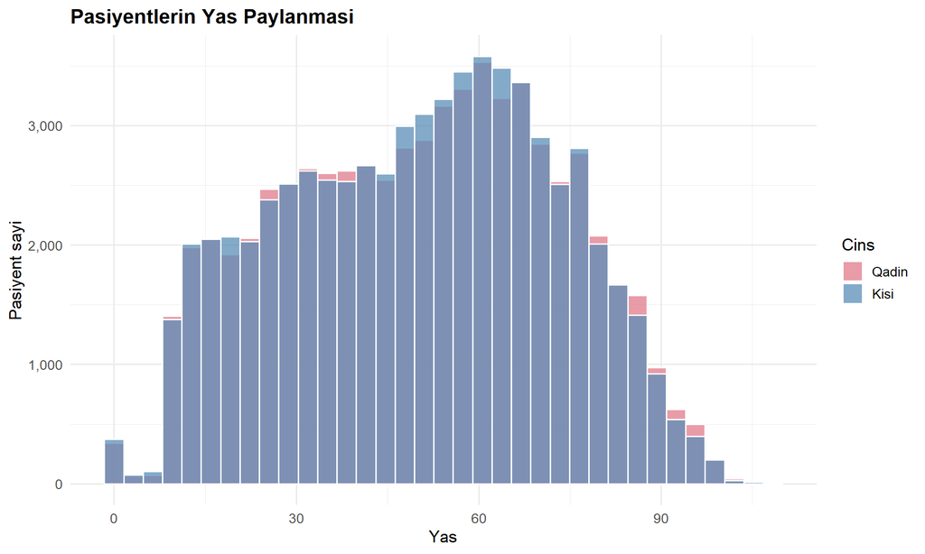

```r
ggplot(patients, aes(x = yas, fill = gender)) +
  geom_histogram(bins = 35, alpha = 0.75, position = "identity", color = "white") +
  scale_fill_manual(values = c("F" = "#e07b8a", "M" = "#5b8db8"),
                    name = "Cins", labels = c("Qadin", "Kisi")) +
  scale_y_continuous(labels = comma) +
  labs(title = "Pasiyentlerin Yas Paylanmasi",
       x = "Yas", y = "Pasiyent sayi") +
  theme_minimal(base_size = 13) +
  theme(plot.title = element_text(face = "bold"))
```

### 4.1.4 Yaş Kateqoriyaları üzrə Boxplot

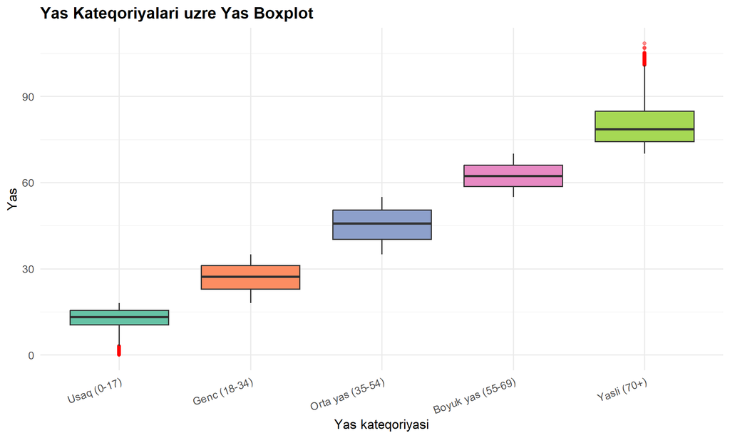

```r
ggplot(patients, aes(x = yas_cat, y = yas, fill = yas_cat)) +
  geom_boxplot(show.legend = FALSE, outlier.color = "red",
               outlier.alpha = 0.4, outlier.size = 1.5) +
  scale_fill_brewer(palette = "Set2") +
  labs(title = "Yas Kateqoriyalari uzre Yas Boxplot",
       x = "Yas kateqoriyasi", y = "Yas") +
  theme_minimal(base_size = 13) +
  theme(plot.title = element_text(face = "bold"),
        axis.text.x = element_text(angle = 20, hjust = 1))
```

### 4.1.5 İrq Paylanması

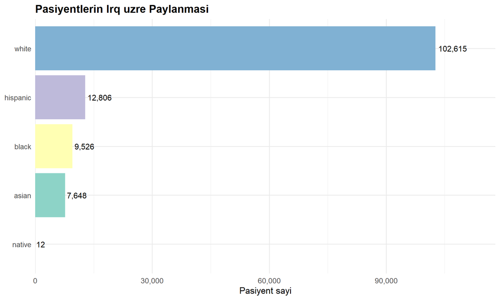

```r
irq <- patients[, .N, by = race][order(-N)]

ggplot(irq, aes(x = reorder(race, N), y = N, fill = race)) +
  geom_col(show.legend = FALSE) +
  geom_text(aes(label = comma(N)), hjust = -0.1, size = 4) +
  coord_flip() +
  scale_y_continuous(labels = comma, expand = expansion(mult = c(0, 0.15))) +
  scale_fill_brewer(palette = "Set3") +
  labs(title = "Pasiyentlerin Irq uzre Paylanmasi",
       x = NULL, y = "Pasiyent sayi") +
  theme_minimal(base_size = 13) +
  theme(plot.title = element_text(face = "bold"))
```

### 4.1.6 Ölüm Statistikası və Yaş Analizi

```r
olum_stat <- patients[, .(
  `Sag olan`       = sum(is.na(deathdate)),
  `Vefat etmis`    = sum(!is.na(deathdate)),
  `Umumi`          = .N,
  `Olum faizi (%)` = round(sum(!is.na(deathdate)) / .N * 100, 1)
)]

kable(olum_stat, caption = "Pasiyentlerin Heyat Statusu") |>
  kable_styling(bootstrap_options = c("striped","hover"), full_width = FALSE)
```

Pasiyentlerin Heyat Statusu

| Sag olan | Vefat etmis | Umumi | Olum faizi (%) |
| --- | --- | --- | --- |
| 99533 | 33074 | 132607 | 24.9 |

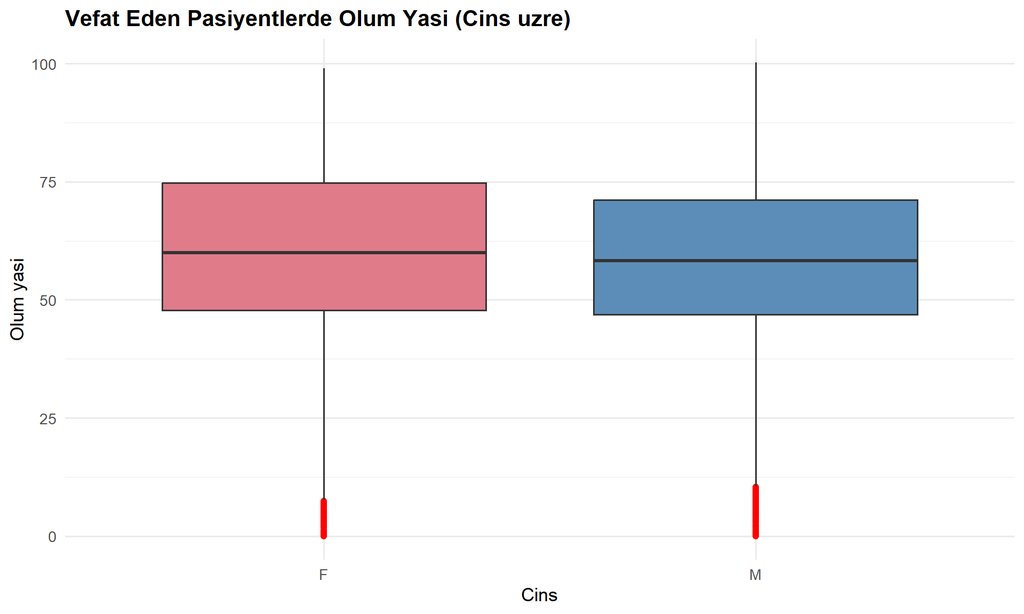

```r
# Ölüm yaşının cinslər üzrə müqayisəsi
olum_yas <- patients[!is.na(deathdate)]

ggplot(olum_yas, aes(x = gender, y = yas, fill = gender)) +
  geom_boxplot(show.legend = FALSE, outlier.color = "red", outlier.alpha = 0.3) +
  scale_fill_manual(values = c("F" = "#e07b8a", "M" = "#5b8db8")) +
  labs(title = "Vefat Eden Pasiyentlerde Olum Yasi (Cins uzre)",
       x = "Cins", y = "Olum yasi") +
  theme_minimal(base_size = 13) +
  theme(plot.title = element_text(face = "bold"))
```

> **Şərh:** Vəfat edən pasiyentlərin ölüm yaşı cinslər üzrə müqayisə edilmişdir. Boxplot hər iki cinsdə ölüm yaşı paylanmasını göstərir.

## 4.2 Müraciətlər (Encounters)

### 4.2.1 İllər üzrə Müraciət Trendi

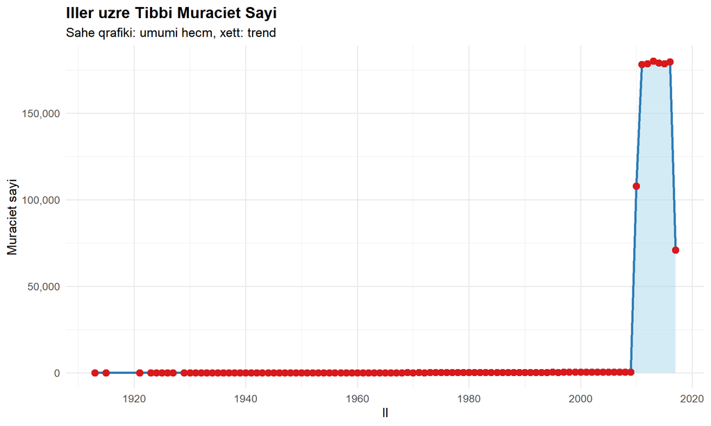

```r
encounters[, il := year(date)]
il_say <- encounters[, .N, by = il][order(il)]

ggplot(il_say, aes(x = il, y = N)) +
  geom_area(fill = "#a8d8ea", alpha = 0.5) +
  geom_line(color = "#2c7bb6", linewidth = 1.2) +
  geom_point(color = "#d7191c", size = 3) +
  scale_y_continuous(labels = comma) +
  scale_x_continuous(breaks = scales::pretty_breaks(n = 8)) +
  labs(title    = "Iller uzre Tibbi Muraciet Sayi",
       subtitle = "Sahe qrafiki: umumi hecm, xett: trend",
       x = "Il", y = "Muraciet sayi") +
  theme_minimal(base_size = 13) +
  theme(plot.title = element_text(face = "bold"))
```

### 4.2.2 Pasiyent Başına Müraciət Nisbəti (Normallaşdırılmış)

```r
# Hər il üçün aktiv pasiyent sayı
il_pasiyent <- encounters[, .(pasiyent_n = uniqueN(patient)), by = il]
il_say_norm <- merge(il_say, il_pasiyent, by = "il")
il_say_norm[, muraciet_per_pasiyent := round(N / pasiyent_n, 2)]

kable(il_say_norm[order(il)],
      col.names = c("Il", "Umumi Muraciet", "Aktiv Pasiyent", "Pasiyent basina Muraciet"),
      caption = "Illər uzrə Normallaşdırılmış Müraciət Sayi") |>
  kable_styling(bootstrap_options = c("striped","hover","condensed"), full_width = FALSE)
```

Illər uzrə Normallaşdırılmış Müraciət Sayi

| Il | Umumi Muraciet | Aktiv Pasiyent | Pasiyent basina Muraciet |
| --- | --- | --- | --- |
| 1913 | 1 | 1 | 1.00 |
| 1915 | 1 | 1 | 1.00 |
| 1921 | 1 | 1 | 1.00 |
| 1923 | 1 | 1 | 1.00 |
| 1924 | 1 | 1 | 1.00 |
| 1925 | 2 | 2 | 1.00 |
| 1926 | 1 | 1 | 1.00 |
| 1927 | 1 | 1 | 1.00 |
| 1929 | 1 | 1 | 1.00 |
| 1930 | 3 | 3 | 1.00 |
| 1931 | 2 | 2 | 1.00 |
| 1932 | 2 | 2 | 1.00 |
| 1933 | 4 | 4 | 1.00 |
| 1934 | 2 | 2 | 1.00 |
| 1935 | 6 | 6 | 1.00 |
| 1936 | 5 | 5 | 1.00 |
| 1937 | 4 | 4 | 1.00 |
| 1938 | 5 | 5 | 1.00 |
| 1939 | 4 | 4 | 1.00 |
| 1940 | 7 | 7 | 1.00 |
| 1941 | 13 | 13 | 1.00 |
| 1942 | 8 | 8 | 1.00 |
| 1943 | 5 | 5 | 1.00 |
| 1944 | 6 | 6 | 1.00 |
| 1945 | 6 | 6 | 1.00 |
| 1946 | 8 | 8 | 1.00 |
| 1947 | 12 | 12 | 1.00 |
| 1948 | 12 | 12 | 1.00 |
| 1949 | 12 | 12 | 1.00 |
| 1950 | 9 | 9 | 1.00 |

[output cut: 67 more lines]

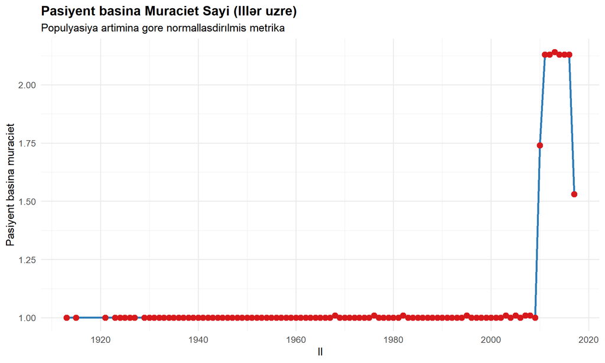

```r
ggplot(il_say_norm, aes(x = il, y = muraciet_per_pasiyent)) +
  geom_line(color = "#2c7bb6", linewidth = 1.2) +
  geom_point(color = "#d7191c", size = 3) +
  scale_x_continuous(breaks = scales::pretty_breaks(n = 8)) +
  labs(title    = "Pasiyent basina Muraciet Sayi (Illər uzre)",
       subtitle = "Populyasiya artimina gore normallasdirılmis metrika",
       x = "Il", y = "Pasiyent basina muraciet") +
  theme_minimal(base_size = 13) +
  theme(plot.title = element_text(face = "bold"))
```

> **Şərh:** Sadə müraciət sayı yerinə pasiyent başına müraciət nisbəti istifadə edilmişdir. Bu, populyasiya artımının təsirini aradan qaldırır və daha düzgün trend analizi imkanı verir.

### 4.2.3 Ən Çox Rast Gəlinən Müraciət Səbəbləri (Top 10)

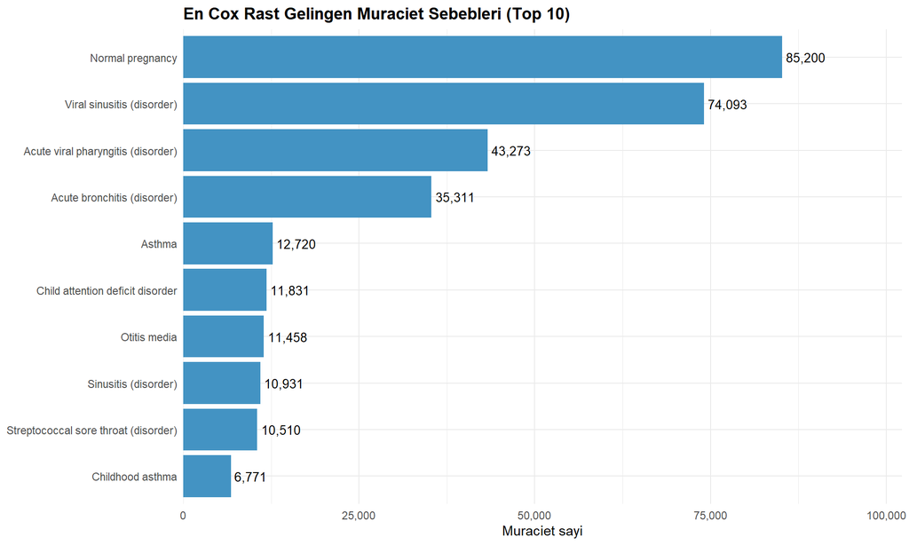

```r
sebeb <- encounters[
  !is.na(reasondescription) & reasondescription != "",
  .N, by = reasondescription
][order(-N)][1:10]

ggplot(sebeb, aes(x = reorder(reasondescription, N), y = N)) +
  geom_col(fill = "#4393c3") +
  geom_text(aes(label = comma(N)), hjust = -0.1, size = 3.5) +
  coord_flip() +
  scale_y_continuous(labels = comma, expand = expansion(mult = c(0, 0.2))) +
  labs(title = "En Cox Rast Gelingen Muraciet Sebebleri (Top 10)",
       x = NULL, y = "Muraciet sayi") +
  theme_minimal(base_size = 11) +
  theme(plot.title = element_text(face = "bold"))
```

## 4.3 Müşahidələr (Observations)

### 4.3.1 BMI Məlumatının Hazırlanması

```r
bmi_data <- observations[description %like% "Body Mass Index" |
                          description %like% "BMI"]
bmi_data[, value := as.numeric(value)]

# Filtrasiya izahı:
# 1. Addım: Fiziki olaraq mümkünsüz dəyərləri çıxar (value > 10 & value < 80)
# 2. Addım: Qalan dəyərlər üzərində IQR anomaliya aşkarlaması
cat("Filtrasiyadan əvvəl sətir sayı:", nrow(bmi_data), "\n")
```

```
## Filtrasiyadan əvvəl sətir sayı: 518213
```

```r
bmi_data <- bmi_data[!is.na(value) & value > 10 & value < 80]
cat("Filtrasiyadan sonra sətir sayı:", nrow(bmi_data), "\n")
```

```
## Filtrasiyadan sonra sətir sayı: 518213
```

```r
cat("Çıxarılan sətir sayı:", nrow(observations[description %like% "Body Mass Index"]) - nrow(bmi_data), "\n")
```

```
## Çıxarılan sətir sayı: 0
```

```r
# fcase() ilə BMI kateqoriyaları
bmi_data[, bmi_cat := fcase(
  value < 18.5,               "Zeif ceki",
  value >= 18.5 & value < 25, "Normal",
  value >= 25   & value < 30, "Artiq ceki",
  value >= 30,                "Obez"
)]

bmi_data[, bmi_cat := factor(bmi_cat,
  levels = c("Zeif ceki", "Normal", "Artiq ceki", "Obez"))]

bmi_data[, .N, by = bmi_cat][order(bmi_cat)] |>
  kable(col.names = c("BMI Kateqoriyasi", "Olcu Sayi"),
        caption = "BMI Kateqoriyalari uzre Paylanma") |>
  kable_styling(bootstrap_options = c("striped","hover"), full_width = FALSE)
```

BMI Kateqoriyalari uzre Paylanma

| BMI Kateqoriyasi | Olcu Sayi |
| --- | --- |
| Zeif ceki | 97841 |
| Normal | 94548 |
| Artiq ceki | 67868 |
| Obez | 257956 |

### 4.3.2 BMI Paylanması

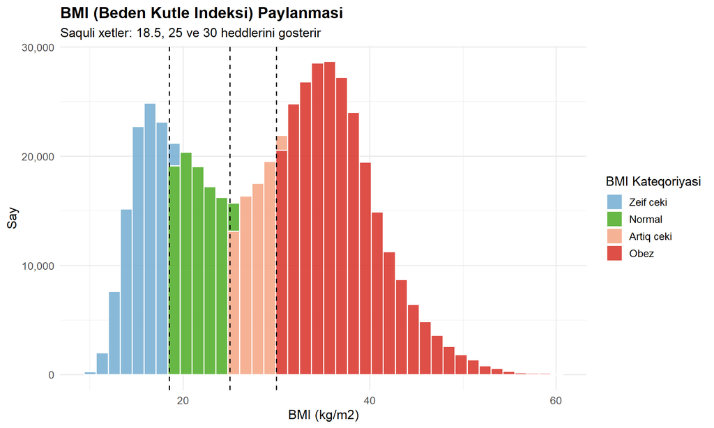

```r
bmi_renk <- c("Zeif ceki"  = "#74add1",
               "Normal"     = "#4dac26",
               "Artiq ceki" = "#f4a582",
               "Obez"       = "#d73027")

ggplot(bmi_data, aes(x = value, fill = bmi_cat)) +
  geom_histogram(bins = 40, color = "white", alpha = 0.85) +
  geom_vline(xintercept = c(18.5, 25, 30),
             linetype = "dashed", color = "black", linewidth = 0.7) +
  scale_fill_manual(values = bmi_renk, name = "BMI Kateqoriyasi") +
  scale_y_continuous(labels = comma) +
  labs(title    = "BMI (Beden Kutle Indeksi) Paylanmasi",
       subtitle = "Saquli xetler: 18.5, 25 ve 30 heddlerini gosterir",
       x = "BMI (kg/m2)", y = "Say") +
  theme_minimal(base_size = 13) +
  theme(plot.title = element_text(face = "bold"))
```

> **Şərh:** BMI paylanması sağa meyllidir. Pasiyentlərin böyük hissəsi artıq çəkili və ya obez kateqoriyasındadır.

### 4.3.3 Qan Təzyiqi və Digər Klinik Göstəricilər

```r
# Sistol qan təzyiqi
bp_sys <- observations[description %like% "Systolic Blood Pressure"]
bp_sys[, value := as.numeric(value)]
bp_sys <- bp_sys[!is.na(value) & value > 50 & value < 250]

# Diastolik qan təzyiqi
bp_dia <- observations[description %like% "Diastolic Blood Pressure"]
bp_dia[, value := as.numeric(value)]
bp_dia <- bp_dia[!is.na(value) & value > 30 & value < 150]

# Xolesterin
xol <- observations[description %like% "Total Cholesterol" | description %like% "Cholesterol"]
xol[, value := as.numeric(value)]
xol <- xol[!is.na(value) & value > 50 & value < 500]

# Qan şəkəri
sekr <- observations[description %like% "Glucose" | description %like% "Blood Glucose"]
sekr[, value := as.numeric(value)]
sekr <- sekr[!is.na(value) & value > 30 & value < 600]

klinik_stat <- data.table(
  Gostərici     = c("Sistol Qan Tezyiqi (mmHg)", "Diastolik Qan Tezyiqi (mmHg)",
                    "Xolesterin (mg/dL)", "Qan Sekeri (mg/dL)"),
  `Olcu Sayi`   = c(nrow(bp_sys), nrow(bp_dia), nrow(xol), nrow(sekr)),
  `Orta`        = c(round(mean(bp_sys$value),1), round(mean(bp_dia$value),1),
                    round(mean(xol$value),1),    round(mean(sekr$value),1)),
  `Median`      = c(round(median(bp_sys$value),1), round(median(bp_dia$value),1),
                    round(median(xol$value),1),     round(median(sekr$value),1)),
  `Std Sapma`   = c(round(sd(bp_sys$value),1), round(sd(bp_dia$value),1),
                    round(sd(xol$value),1),     round(sd(sekr$value),1))
)

kable(klinik_stat, caption = "Klinik Gostericilerin Deskriptiv Statistikasi") |>
  kable_styling(bootstrap_options = c("striped","hover"), full_width = FALSE)
```

Klinik Gostericilerin Deskriptiv Statistikasi

| Gostərici | Olcu Sayi | Orta | Median | Std Sapma |
| --- | --- | --- | --- | --- |
| Sistol Qan Tezyiqi (mmHg) | 588656 | 129.5 | 124 | 24.0 |
| Diastolik Qan Tezyiqi (mmHg) | 588656 | 84.6 | 82 | 12.1 |
| Xolesterin (mg/dL) | 389709 | 120.2 | 93 | 56.5 |
| Qan Sekeri (mg/dL) | 158124 | 90.3 | 85 | 25.2 |

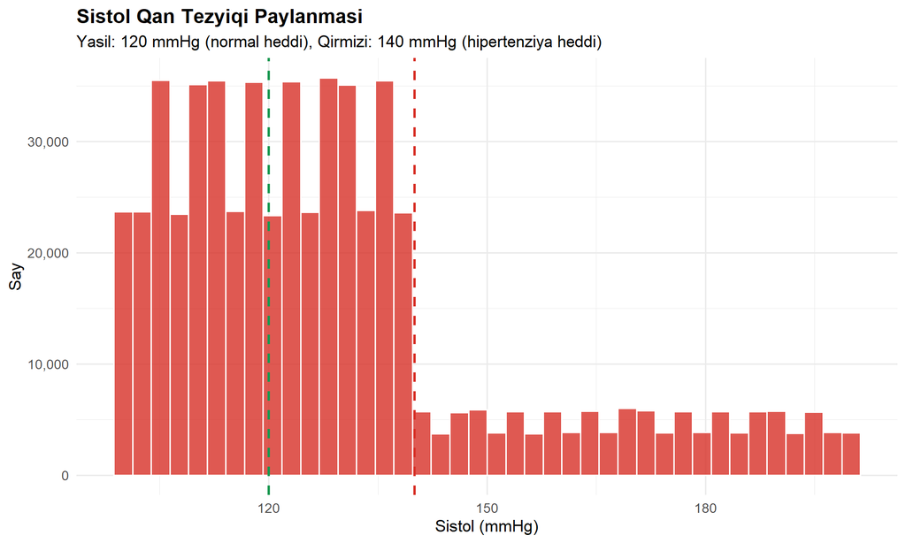

```r
# Sistol qan təzyiqi histogramı
ggplot(bp_sys, aes(x = value)) +
  geom_histogram(bins = 40, fill = "#d73027", color = "white", alpha = 0.8) +
  geom_vline(xintercept = 120, linetype = "dashed", color = "#1a9850", linewidth = 1) +
  geom_vline(xintercept = 140, linetype = "dashed", color = "#d73027", linewidth = 1) +
  scale_y_continuous(labels = comma) +
  labs(title    = "Sistol Qan Tezyiqi Paylanmasi",
       subtitle = "Yasil: 120 mmHg (normal heddi), Qirmizi: 140 mmHg (hipertenziya heddi)",
       x = "Sistol (mmHg)", y = "Say") +
  theme_minimal(base_size = 13) +
  theme(plot.title = element_text(face = "bold"))
```

### 4.3.4 BMI Kateqoriyaları üzrə Boxplot

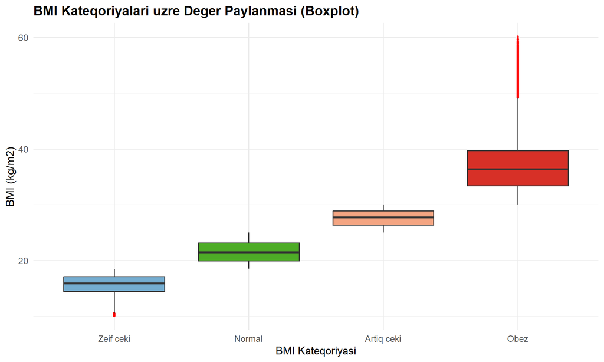

```r
ggplot(bmi_data, aes(x = bmi_cat, y = value, fill = bmi_cat)) +
  geom_boxplot(show.legend = FALSE, outlier.color = "red",
               outlier.alpha = 0.3, outlier.size = 1) +
  scale_fill_manual(values = bmi_renk) +
  labs(title = "BMI Kateqoriyalari uzre Deger Paylanmasi (Boxplot)",
       x = "BMI Kateqoriyasi", y = "BMI (kg/m2)") +
  theme_minimal(base_size = 13) +
  theme(plot.title = element_text(face = "bold"))
```

# 5 Cədvəllərin Birləşdirilməsi (JOIN)

```r
enc_pat <- merge(
  encounters,
  patients[, .(id, yas, yas_cat, gender, race, marital)],
  by.x = "patient", by.y = "id", all.x = TRUE
)

bmi_pat <- merge(
  bmi_data[, .(patient, date, value, bmi_cat)],
  patients[, .(id, yas, yas_cat, gender, race)],
  by.x = "patient", by.y = "id", all.x = TRUE
)

cat("enc_pat setir sayi: ", format(nrow(enc_pat), big.mark=","), "\n")
```

```
## enc_pat setir sayi:  1,263,669
```

```r
cat("bmi_pat setir sayi: ", format(nrow(bmi_pat), big.mark=","), "\n")
```

```
## bmi_pat setir sayi:  518,213
```

## 5.1 Yaş Kateqoriyası üzrə Müraciət Sayı

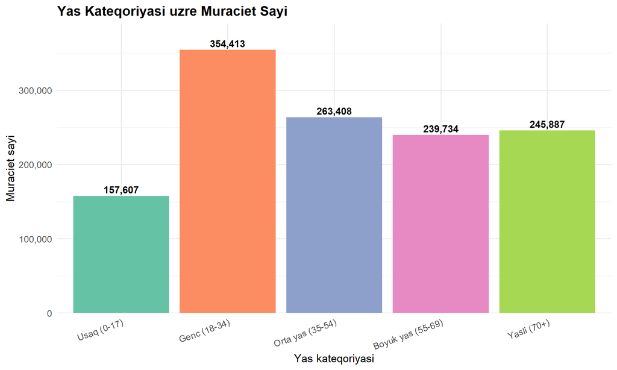

```r
yas_enc_plot <- enc_pat[!is.na(yas_cat), .N, by = yas_cat][order(yas_cat)]

ggplot(yas_enc_plot, aes(x = yas_cat, y = N, fill = yas_cat)) +
  geom_col(show.legend = FALSE) +
  geom_text(aes(label = comma(N)), vjust = -0.4, size = 4, fontface = "bold") +
  scale_fill_brewer(palette = "Set2") +
  scale_y_continuous(labels = comma, expand = expansion(mult = c(0, 0.1))) +
  labs(title = "Yas Kateqoriyasi uzre Muraciet Sayi",
       x = "Yas kateqoriyasi", y = "Muraciet sayi") +
  theme_minimal(base_size = 13) +
  theme(plot.title = element_text(face = "bold"),
        axis.text.x = element_text(angle = 20, hjust = 1))
```

## 5.2 Facet: Cins və Yaş üzrə Müraciət

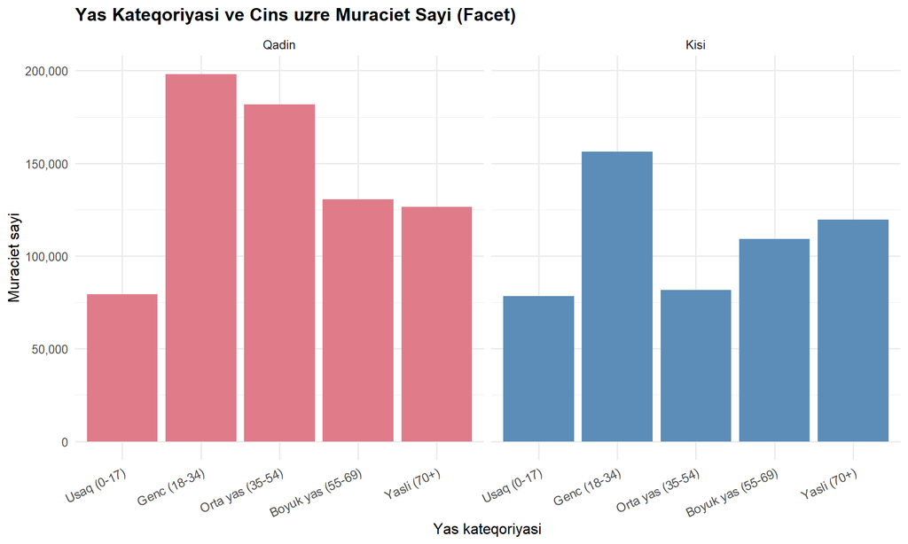

```r
yas_cins <- enc_pat[!is.na(yas_cat) & !is.na(gender), .N, by = .(yas_cat, gender)]

ggplot(yas_cins, aes(x = yas_cat, y = N, fill = gender)) +
  geom_col(position = "dodge") +
  scale_fill_manual(values = c("F" = "#e07b8a", "M" = "#5b8db8"),
                    name = "Cins", labels = c("Qadin","Kisi")) +
  scale_y_continuous(labels = comma) +
  facet_wrap(~ gender, labeller = labeller(gender = c("F"="Qadin","M"="Kisi"))) +
  labs(title = "Yas Kateqoriyasi ve Cins uzre Muraciet Sayi (Facet)",
       x = "Yas kateqoriyasi", y = "Muraciet sayi") +
  theme_minimal(base_size = 12) +
  theme(plot.title = element_text(face = "bold"),
        axis.text.x = element_text(angle = 25, hjust = 1),
        legend.position = "none")
```

# 6 Anomaliyalar

## 6.1 IQR Metodu ilə BMI Anomaliyaları

```r
Q1_bmi  <- quantile(bmi_data$value, 0.25, na.rm = TRUE)
Q3_bmi  <- quantile(bmi_data$value, 0.75, na.rm = TRUE)
IQR_bmi <- Q3_bmi - Q1_bmi
alt_bmi <- Q1_bmi - 1.5 * IQR_bmi
ust_bmi <- Q3_bmi + 1.5 * IQR_bmi

bmi_data[, anomaliya := value < alt_bmi | value > ust_bmi]

anom_stat <- data.table(
  Gostərici = c("Q1 (25. persentil)", "Q3 (75. persentil)", "IQR",
                "Alt hedd (Q1-1.5xIQR)", "Ust hedd (Q3+1.5xIQR)",
                "Anomal BMI sayi", "Anomal BMI faizi (%)"),
  Deger = c(round(Q1_bmi,2), round(Q3_bmi,2), round(IQR_bmi,2),
            round(alt_bmi,2), round(ust_bmi,2),
            bmi_data[anomaliya==TRUE, .N],
            round(bmi_data[anomaliya==TRUE, .N] / nrow(bmi_data) * 100, 2))
)

kable(anom_stat, caption = "BMI Anomaliya Analizi (IQR Metodu)") |>
  kable_styling(bootstrap_options = c("striped","hover"), full_width = FALSE)
```

BMI Anomaliya Analizi (IQR Metodu)

| Gostərici | Deger |
| --- | --- |
| Q1 (25. persentil) | 20.44 |
| Q3 (75. persentil) | 36.28 |
| IQR | 15.84 |
| Alt hedd (Q1-1.5xIQR) | -3.32 |
| Ust hedd (Q3+1.5xIQR) | 60.04 |
| Anomal BMI sayi | 5.00 |
| Anomal BMI faizi (%) | 0.00 |

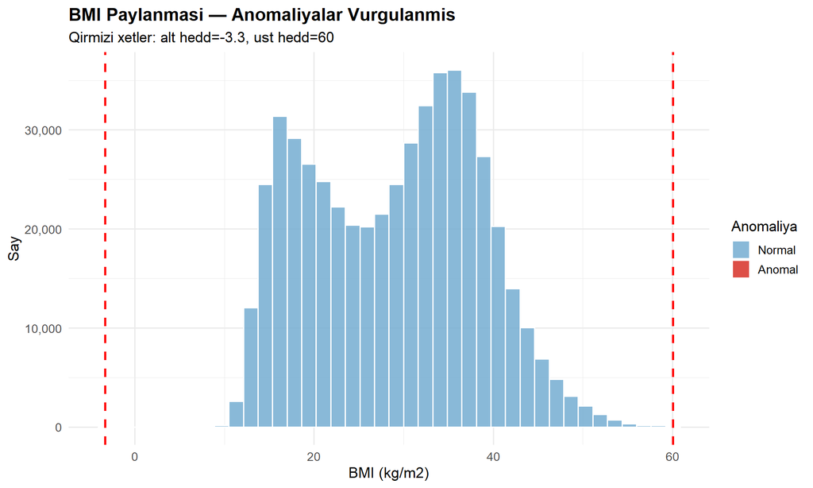

```r
ggplot(bmi_data, aes(x = value, fill = anomaliya)) +
  geom_histogram(bins = 40, color = "white", alpha = 0.85) +
  geom_vline(xintercept = c(alt_bmi, ust_bmi),
             linetype = "dashed", color = "red", linewidth = 1) +
  scale_fill_manual(values = c("FALSE" = "#74add1", "TRUE" = "#d73027"),
                    name = "Anomaliya", labels = c("Normal", "Anomal")) +
  scale_y_continuous(labels = comma) +
  labs(title    = "BMI Paylanmasi — Anomaliyalar Vurgulanmis",
       subtitle = paste0("Qirmizi xetler: alt hedd=", round(alt_bmi,1),
                         ", ust hedd=", round(ust_bmi,1)),
       x = "BMI (kg/m2)", y = "Say") +
  theme_minimal(base_size = 13) +
  theme(plot.title = element_text(face = "bold"))
```

> **Şərh:** IQR metodunun iki addımı: əvvəlcə fiziki olaraq mümkünsüz dəyərlər (10-80 xaricindəkilər) çıxarılmışdır, sonra qalan dəyərlər üzərində IQR metodu tətbiq edilmişdir. Anomal dəyərlər ölçüm xətası, nadir tibbi vəziyyət və ya data keyfiyyəti problemi ilə izah oluna bilər.

## 6.2 Müraciət Sayında Anomaliyalar

```r
enc_per_pat <- encounters[, .N, by = patient]

Q1_e  <- quantile(enc_per_pat$N, 0.25)
Q3_e  <- quantile(enc_per_pat$N, 0.75)
IQR_e <- Q3_e - Q1_e
ust_e <- Q3_e + 1.5 * IQR_e

enc_per_pat[, anomaliya := N > ust_e]
cat("Anomal muraciet heddi: >", round(ust_e, 0), "\n")
```

```
## Anomal muraciet heddi: > 25
```

```r
cat("Anomal pasiyent sayi:", enc_per_pat[anomaliya==TRUE, .N], "\n")
```

```
## Anomal pasiyent sayi: 6137
```

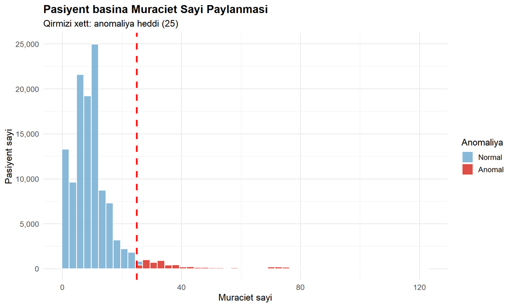

```r
ggplot(enc_per_pat, aes(x = N, fill = anomaliya)) +
  geom_histogram(bins = 50, color = "white", alpha = 0.85) +
  geom_vline(xintercept = ust_e, color = "red", linetype = "dashed", linewidth = 1.2) +
  scale_fill_manual(values = c("FALSE" = "#74add1", "TRUE" = "#d73027"),
                    name = "Anomaliya", labels = c("Normal", "Anomal")) +
  scale_y_continuous(labels = comma) +
  labs(title    = "Pasiyent basina Muraciet Sayi Paylanmasi",
       subtitle = paste0("Qirmizi xett: anomaliya heddi (", round(ust_e,0), ")"),
       x = "Muraciet sayi", y = "Pasiyent sayi") +
  theme_minimal(base_size = 13) +
  theme(plot.title = element_text(face = "bold"))
```

# 7 Korrelyasiya Analizi

## 7.1 Yas-BMI Birləşdirilmiş Məlumat

```r
bmi_yas <- merge(
  bmi_data[, .(patient, value, bmi_cat)],
  patients[, .(id, yas, yas_cat, gender)],
  by.x = "patient", by.y = "id", all.x = TRUE
)
bmi_yas <- bmi_yas[!is.na(yas) & !is.na(value)]
```

## 7.2 Pearson vs Spearman Korrelyasiya

```r
# Pearson korrelyasiya (normal paylanma fərzi ilə)
kor_pearson <- cor.test(bmi_yas$yas, bmi_yas$value, method = "pearson")

# Spearman korrelyasiya (paylanma fərzindən azad)
kor_spearman <- cor.test(bmi_yas$yas, bmi_yas$value, method = "spearman")

kor_muq <- data.table(
  Metod        = c("Pearson", "Spearman"),
  `r / rho`    = c(round(kor_pearson$estimate, 4),
                   round(kor_spearman$estimate, 4)),
  `p-deger`    = c(format(kor_pearson$p.value, scientific=TRUE, digits=3),
                   format(kor_spearman$p.value, scientific=TRUE, digits=3)),
  Qiymetlen    = c(ifelse(abs(kor_pearson$estimate) < 0.2,  "Cox zeif",
                   ifelse(abs(kor_pearson$estimate) < 0.4,  "Zeif",
                   ifelse(abs(kor_pearson$estimate) < 0.6,  "Orta", "Guclu"))),
                   ifelse(abs(kor_spearman$estimate) < 0.2, "Cox zeif",
                   ifelse(abs(kor_spearman$estimate) < 0.4, "Zeif",
                   ifelse(abs(kor_spearman$estimate) < 0.6, "Orta", "Guclu"))))
)

kable(kor_muq, caption = "Pearson vs Spearman Korrelyasiya Muqayisesi") |>
  kable_styling(bootstrap_options = c("striped","hover"), full_width = FALSE)
```

Pearson vs Spearman Korrelyasiya Muqayisesi

| Metod | r / rho | p-deger | Qiymetlen |
| --- | --- | --- | --- |
| Pearson | 0.7092 | 0e+00 | Guclu |
| Spearman | 0.6762 | 0e+00 | Guclu |

## 7.3 Geniş Korrelyasiya Matrisi

```r
# BMI + sistol + diastolik + xolesterin + yaş korrelyasiya matrisi
bp_sys_pat <- merge(bp_sys[, .(patient, bp_sys = value)],
                    patients[, .(id, yas)], by.x="patient", by.y="id")
bp_dia_pat <- merge(bp_dia[, .(patient, bp_dia = value)],
                    patients[, .(id)], by.x="patient", by.y="id")
bmi_min    <- bmi_data[, .(patient, bmi = value)]

# En son ölçünü götür (unique problem həlli: hər pasiyent üçün son BMI)
bmi_son <- bmi_data[order(patient, date)][, .SD[.N], by = patient][, .(patient, bmi = value)]

kor_data <- merge(bmi_son, bp_sys_pat[, .(patient, bp_sys, yas)], by="patient")

if (nrow(kor_data) > 100) {
  kor_matrix <- cor(kor_data[, .(bmi, bp_sys, yas)], use="complete.obs")
  kable(round(kor_matrix, 3), caption = "Korrelyasiya Matrisi (BMI, Sistol QT, Yas)") |>
    kable_styling(bootstrap_options = c("striped","hover"), full_width = FALSE)
}
```

Korrelyasiya Matrisi (BMI, Sistol QT, Yas)

|  | bmi | bp_sys | yas |
| --- | --- | --- | --- |
| bmi | 1.000 | 0.254 | 0.705 |
| bp_sys | 0.254 | 1.000 | 0.272 |
| yas | 0.705 | 0.272 | 1.000 |

## 7.4 Scatter Plot + Reqressiya Xətti

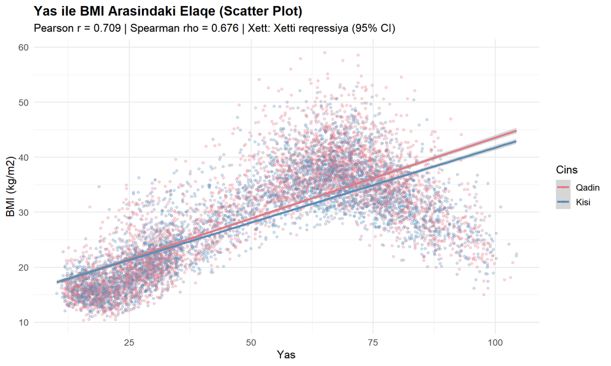

```r
set.seed(42)
numune <- bmi_yas[sample(.N, min(8000, .N))]

ggplot(numune, aes(x = yas, y = value, color = gender)) +
  geom_point(alpha = 0.25, size = 1.2) +
  geom_smooth(method = "lm", se = TRUE, linewidth = 1.2) +
  scale_color_manual(values = c("F" = "#e07b8a", "M" = "#5b8db8"),
                     name = "Cins", labels = c("Qadin","Kisi")) +
  labs(title    = "Yas ile BMI Arasindaki Elaqe (Scatter Plot)",
       subtitle = paste0("Pearson r = ", round(kor_pearson$estimate, 3),
                         " | Spearman rho = ", round(kor_spearman$estimate, 3),
                         " | Xett: Xetti reqressiya (95% CI)"),
       x = "Yas", y = "BMI (kg/m2)") +
  theme_minimal(base_size = 13) +
  theme(plot.title = element_text(face = "bold"))
```

# 8 Reqressiya Analizi

## 8.1 Sadə Xətti Reqressiya (BMI ~ Yaş)

```r
model_sade <- lm(value ~ yas, data = bmi_yas)
summary(model_sade)
```

```
##
## Call:
## lm(formula = value ~ yas, data = bmi_yas)
##
## Residuals:
##      Min       1Q   Median       3Q      Max
## -31.1958  -4.0698  -0.3646   4.1713  28.8795
##
## Coefficients:
##              Estimate Std. Error t value Pr(>|t|)
## (Intercept) 1.460e+01  2.189e-02   667.2   <2e-16 ***
## yas         2.771e-01  3.831e-04   723.3   <2e-16 ***
## ---
## Signif. codes:  0 '***' 0.001 '**' 0.01 '*' 0.05 '.' 0.1 ' ' 1
##
## Residual standard error: 6.642 on 517138 degrees of freedom
## Multiple R-squared:  0.5029, Adjusted R-squared:  0.5029
## F-statistic: 5.232e+05 on 1 and 517138 DF,  p-value: < 2.2e-16
```

```r
coef_sade <- summary(model_sade)$coefficients

reg_stat <- data.table(
  Gostərici = c("R2 (Determinasiya emsali)",
                "Duzeldilmis R2",
                "Kesisme noktesi (intercept)",
                "Yasin emsali",
                "p-deger (intercept)",
                "p-deger (yas)"),
  Deger = c(
    round(summary(model_sade)$r.squared, 4),
    round(summary(model_sade)$adj.r.squared, 4),
    round(coef_sade[1,1], 4),
    round(coef_sade[2,1], 4),
    format(coef_sade[1,4], scientific=TRUE, digits=3),
    format(coef_sade[2,4], scientific=TRUE, digits=3)
  )
)

kable(reg_stat, caption = "Sade Xetti Reqressiya Neticeleri (BMI ~ Yas)") |>
  kable_styling(bootstrap_options = c("striped","hover"), full_width = FALSE)
```

Sade Xetti Reqressiya Neticeleri (BMI ~ Yas)

| Gostərici | Deger |
| --- | --- |
| R2 (Determinasiya emsali) | 0.5029 |
| Duzeldilmis R2 | 0.5029 |
| Kesisme noktesi (intercept) | 14.6016 |
| Yasin emsali | 0.2771 |
| p-deger (intercept) | 0e+00 |
| p-deger (yas) | 0e+00 |

### 8.1.1 Residual Diaqnostikası

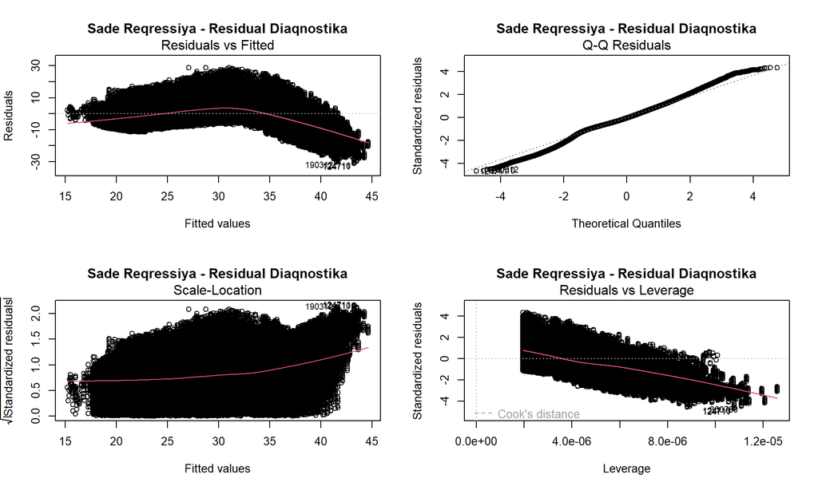

```r
par(mfrow = c(2, 2))
plot(model_sade, main = "Sade Reqressiya - Residual Diaqnostika")
```

```r
par(mfrow = c(1, 1))
```

> **Şərh:** Residual diaqnostika 4 qrafik vasitəsilə xətti reqressiyanın dörd əsas fərziyyəsini yoxlayır: (1) xəttililik, (2) homoskedastiklik, (3) normallik, (4) müstəqillik. Bu yoxlamalar modelin etibarlılığını qiymətləndirmək üçün vacibdir.

## 8.2 Mürəkkəb Xətti Reqressiya (BMI ~ Yaş + Cins)

```r
# Gender encoding: Kisi (M) = 0 (reference), Qadin (F) = 1
# Bu o demekdir ki: emsalin muster yonu Qadinlarin BMI-nin
# Kisilerden ne qeder yuksek/asagi oldugunu gosterir
bmi_yas[, gender_n := ifelse(gender == "F", 1, 0)]

model_cox <- lm(value ~ yas + gender_n, data = bmi_yas)
summary(model_cox)
```

```
##
## Call:
## lm(formula = value ~ yas + gender_n, data = bmi_yas)
##
## Residuals:
##      Min       1Q   Median       3Q      Max
## -31.5453  -4.0648  -0.3412   4.1805  28.5261
##
## Coefficients:
##              Estimate Std. Error t value Pr(>|t|)
## (Intercept) 1.424e+01  2.375e-02  599.53   <2e-16 ***
## yas         2.771e-01  3.826e-04  724.20   <2e-16 ***
## gender_n    7.202e-01  1.845e-02   39.04   <2e-16 ***
## ---
## Signif. codes:  0 '***' 0.001 '**' 0.01 '*' 0.05 '.' 0.1 ' ' 1
##
## Residual standard error: 6.632 on 517137 degrees of freedom
## Multiple R-squared:  0.5044, Adjusted R-squared:  0.5044
## F-statistic: 2.631e+05 on 2 and 517137 DF,  p-value: < 2.2e-16
```

```r
coef_cox <- summary(model_cox)$coefficients

reg_cox <- data.table(
  Deyisen     = c("Kesisme noktesi", "Yas", "Cins (Qadin=1, Kisi=0)"),
  Emsal       = round(coef_cox[,1], 4),
  `Std Xeta`  = round(coef_cox[,2], 4),
  `t-deger`   = round(coef_cox[,3], 4),
  `p-deger`   = format(coef_cox[,4], scientific=TRUE, digits=3)
)

kable(reg_cox, caption = "Murekkeb Xetti Reqressiya Neticeleri (BMI ~ Yas + Cins)") |>
  kable_styling(bootstrap_options = c("striped","hover"), full_width = FALSE)
```

Murekkeb Xetti Reqressiya Neticeleri (BMI ~ Yas + Cins)

| Deyisen | Emsal | Std Xeta | t-deger | p-deger |
| --- | --- | --- | --- | --- |
| Kesisme noktesi | 14.2386 | 0.0237 | 599.5355 | 0e+00 |
| Yas | 0.2771 | 0.0004 | 724.1975 | 0e+00 |
| Cins (Qadin=1, Kisi=0) | 0.7202 | 0.0184 | 39.0383 | 0e+00 |

```r
cat("R2:", round(summary(model_cox)$r.squared, 4), "\n")
```

```
## R2: 0.5044
```

```r
cat("Duzeldilmis R2:", round(summary(model_cox)$adj.r.squared, 4), "\n")
```

```
## Duzeldilmis R2: 0.5044
```

```r
cat("Izah: Reference kateqoriya = Kisi (gender_n = 0)\n")
```

```
## Izah: Reference kateqoriya = Kisi (gender_n = 0)
```

```r
cat("Cinsin emsali muster yonu: Qadinlarin BMI-si Kisilerden ne qeder ferqlidir\n")
```

```
## Cinsin emsali muster yonu: Qadinlarin BMI-si Kisilerden ne qeder ferqlidir
```

### 8.2.1 Residual Diaqnostikası (Mürəkkəb Model)

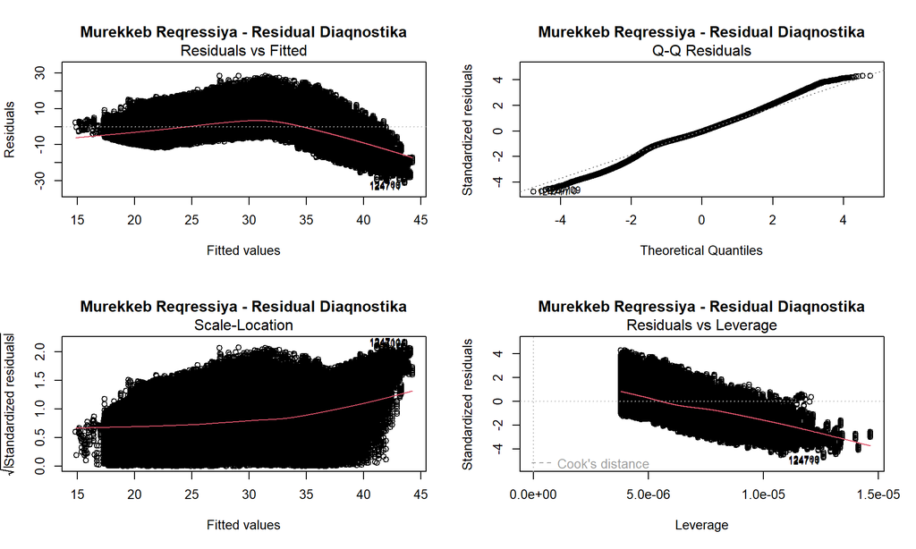

```r
par(mfrow = c(2, 2))
plot(model_cox, main = "Murekkeb Reqressiya - Residual Diaqnostika")
```

```r
par(mfrow = c(1, 1))
```

### 8.2.2 VIF (Multikollinearlik) Yoxlaması

```r
vif_values <- vif(model_cox)
cat("VIF deyerleri:\n")
```

```
## VIF deyerleri:
```

```r
print(vif_values)
```

```
##      yas gender_n
## 1.000025 1.000025
```

```r
cat("\nIzah: VIF < 5 → multikollinearlik problemi yoxdur\n")
```

```
##
## Izah: VIF < 5 → multikollinearlik problemi yoxdur
```

```r
cat("VIF >= 5 → orta multikollinearlik\n")
```

```
## VIF >= 5 → orta multikollinearlik
```

```r
cat("VIF >= 10 → ciddi multikollinearlik\n")
```

```
## VIF >= 10 → ciddi multikollinearlik
```

> **Şərh:** VIF (Variance Inflation Factor) dəyişənlər arasında multikollinearliği ölçür. VIF < 5 olan halda multikollinearlik problemi yoxdur və model əmsalları etibarlıdır.

### 8.2.3 Cross-Validation ilə Model Etibarlılığı

```r
set.seed(42)
cv_data <- bmi_yas[!is.na(value) & !is.na(yas) & !is.na(gender_n),
                   .(value, yas, gender_n)]
cv_data <- as.data.frame(cv_data)

train_control <- trainControl(method = "cv", number = 10)
model_cv <- train(value ~ yas + gender_n,
                  data      = cv_data,
                  method    = "lm",
                  trControl = train_control)

cv_netice <- data.table(
  Metrika = c("RMSE (10-fold CV)", "R2 (10-fold CV)", "MAE (10-fold CV)"),
  Deger   = c(round(model_cv$results$RMSE, 4),
              round(model_cv$results$Rsquared, 4),
              round(model_cv$results$MAE, 4))
)

kable(cv_netice, caption = "10-Fold Cross-Validation Neticeleri") |>
  kable_styling(bootstrap_options = c("striped","hover"), full_width = FALSE)
```

10-Fold Cross-Validation Neticeleri

| Metrika | Deger |
| --- | --- |
| RMSE (10-fold CV) | 6.6317 |
| R2 (10-fold CV) | 0.5044 |
| MAE (10-fold CV) | 5.1182 |

> **Şərh:** 10-fold cross-validation modelin yeni məlumat üzərindəki ümumi performansını qiymətləndirir. CV nəticələri train datasındakı nəticələrə yaxın olarsa, model overfitting etməmişdir.

# 9 Proqnoz və Fərziyyələr

```r
enc_yas <- merge(
  enc_per_pat[, .(patient, enc_n = N)],
  patients[, .(id, yas_cat)],
  by.x = "patient", by.y = "id"
)

yas_enc_stat <- enc_yas[!is.na(yas_cat), .(
  `Orta muraciet`   = round(mean(enc_n), 1),
  `Median muraciet` = round(median(enc_n), 1),
  `Pasiyent sayi`   = .N
), by = yas_cat][order(yas_cat)]

kable(yas_enc_stat, caption = "Yas Kateqoriyasi uzre Muraciet Statistikasi") |>
  kable_styling(bootstrap_options = c("striped","hover"), full_width = FALSE)
```

Yas Kateqoriyasi uzre Muraciet Statistikasi

| yas_cat | Orta muraciet | Median muraciet | Pasiyent sayi |
| --- | --- | --- | --- |
| Usaq (0-17) | 14.2 | 15 | 11089 |
| Genc (18-34) | 14.9 | 10 | 23796 |
| Orta yas (35-54) | 8.3 | 5 | 31662 |
| Boyuk yas (55-69) | 8.6 | 8 | 27808 |
| Yasli (70+) | 10.3 | 10 | 23984 |

```r
# Kruskal-Wallis testi (qruplar arasında fərq statistik olaraq mənalıdırmı?)
kw_test <- kruskal.test(enc_n ~ yas_cat, data = enc_yas[!is.na(yas_cat)])
cat("Kruskal-Wallis testi:\n")
```

```
## Kruskal-Wallis testi:
```

```r
cat("chi-kare =", round(kw_test$statistic, 2), "\n")
```

```
## chi-kare = 19247.68
```

```r
cat("p-deger =", format(kw_test$p.value, scientific=TRUE, digits=3), "\n")
```

```
## p-deger = 0e+00
```

```r
cat("Netice:", ifelse(kw_test$p.value < 0.05,
    "p < 0.05 → Qruplar arasinda statistik olaraq menali ferq var (TESDIQLENIB)",
    "p >= 0.05 → Statistik olaraq menali ferq yoxdur (TESDIQLENMIR)"), "\n")
```

```
## Netice: p < 0.05 → Qruplar arasinda statistik olaraq menali ferq var (TESDIQLENIB)
```

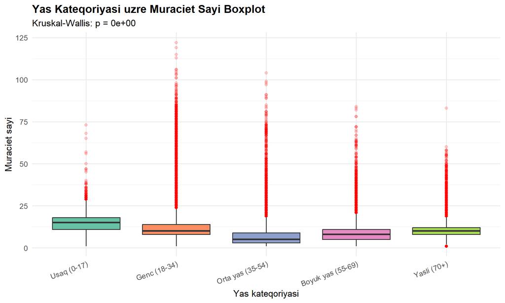

```r
ggplot(enc_yas[!is.na(yas_cat)], aes(x = yas_cat, y = enc_n, fill = yas_cat)) +
  geom_boxplot(show.legend = FALSE, outlier.alpha = 0.2, outlier.color = "red") +
  scale_fill_brewer(palette = "Set2") +
  scale_y_continuous(labels = comma) +
  labs(title    = "Yas Kateqoriyasi uzre Muraciet Sayi Boxplot",
       subtitle = paste0("Kruskal-Wallis: p = ",
                         format(kw_test$p.value, scientific=TRUE, digits=3)),
       x = "Yas kateqoriyasi", y = "Muraciet sayi") +
  theme_minimal(base_size = 13) +
  theme(plot.title  = element_text(face = "bold"),
        axis.text.x = element_text(angle = 20, hjust = 1))
```

> **Şərh:** Kruskal-Wallis testi qruplar arasındakı fərqin statistik əhəmiyyətini ölçür. p < 0.05 olduqda fərziyyə statistik test əsasında təsdiqlənir.

```r
# Hər pasiyent üçün ən son BMI ölçüsü götürülür
# (unique() ilk sıranı deyil, ən son tarixi götürür)
bmi_son_enc <- bmi_data[order(patient, date)][, .SD[.N], by = patient][, .(patient, bmi_cat)]

bmi_enc <- merge(bmi_son_enc, enc_per_pat[, .(patient, enc_n = N)], by = "patient")

bmi_enc_stat <- bmi_enc[, .(
  `Orta muraciet` = round(mean(enc_n), 1),
  `Median`        = round(median(enc_n), 1),
  `Pasiyent sayi` = .N
), by = bmi_cat][order(bmi_cat)]

kable(bmi_enc_stat, caption = "BMI Kateqoriyasi uzre Muraciet Statistikasi") |>
  kable_styling(bootstrap_options = c("striped","hover"), full_width = FALSE)
```

BMI Kateqoriyasi uzre Muraciet Statistikasi

| bmi_cat | Orta muraciet | Median | Pasiyent sayi |
| --- | --- | --- | --- |
| Zeif ceki | 15.6 | 14 | 13356 |
| Normal | 14.1 | 10 | 19683 |
| Artiq ceki | 10.9 | 9 | 18593 |
| Obez | 10.2 | 9 | 53073 |

```r
# Kruskal-Wallis testi
kw_bmi <- kruskal.test(enc_n ~ bmi_cat, data = bmi_enc[!is.na(bmi_cat)])
cat("Kruskal-Wallis testi (BMI ~ Muraciet):\n")
```

```
## Kruskal-Wallis testi (BMI ~ Muraciet):
```

```r
cat("p-deger =", format(kw_bmi$p.value, scientific=TRUE, digits=3), "\n")
```

```
## p-deger = 0e+00
```

```r
cat("Netice:", ifelse(kw_bmi$p.value < 0.05,
    "p < 0.05 → TESDIQLENIB",
    "p >= 0.05 → TESDIQLENMIR"), "\n")
```

```
## Netice: p < 0.05 → TESDIQLENIB
```

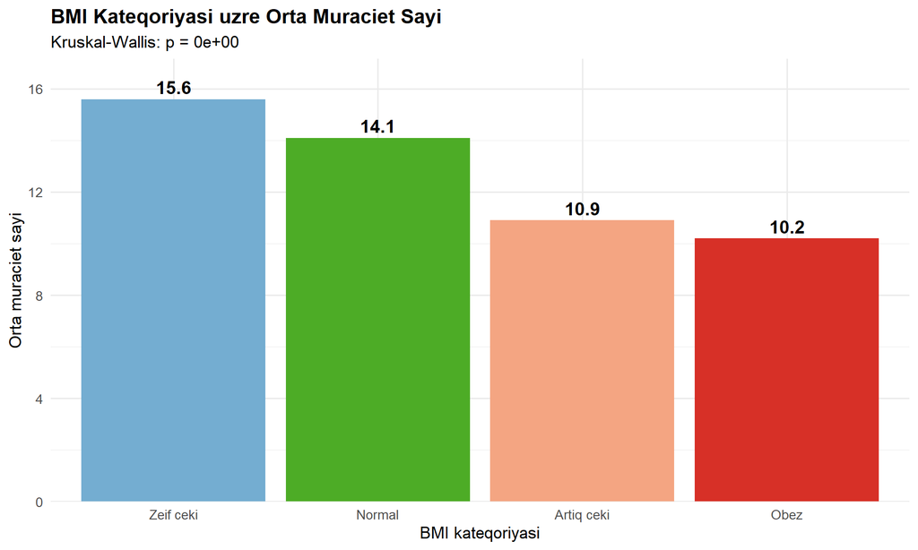

```r
ggplot(bmi_enc_stat, aes(x = bmi_cat, y = `Orta muraciet`, fill = bmi_cat)) +
  geom_col(show.legend = FALSE) +
  geom_text(aes(label = `Orta muraciet`), vjust = -0.4, size = 5, fontface = "bold") +
  scale_fill_manual(values = bmi_renk) +
  scale_y_continuous(expand = expansion(mult = c(0, 0.1))) +
  labs(title    = "BMI Kateqoriyasi uzre Orta Muraciet Sayi",
       subtitle = paste0("Kruskal-Wallis: p = ",
                         format(kw_bmi$p.value, scientific=TRUE, digits=3)),
       x = "BMI kateqoriyasi", y = "Orta muraciet sayi") +
  theme_minimal(base_size = 13) +
  theme(plot.title = element_text(face = "bold"))
```

> **Şərh:** Hər pasiyent üçün ən son BMI ölçüsü seçilmişdir (tarixə görə sıralanıb, sonuncu götürülüb). Bu, random ilk ölçünün seçilməsindən daha metodoloji cəhətdən düzgündür.